# Object Oriented Programming With R

2017-6-16

## What is Object Oriented Programming?

- Object Oriented Programming (OOP) is a programming paradigm
- Involves the grouping of data with functions
  - These functions are used to apply changes to the contained data
- A collection of Data and Functions is called a class
- A Class is a blue print, from which instances of an object can be made

## Pros and Cons of OOP

Like all programming methodologies, there are upsides and downsides

| Pros | Cons |
| --- | --- |
| Scalable and Manageable Code bases | Can be time consuming to design and produce |
| Less Code Redundancy | Not always worth the effor for small projects |
| Portable and Re-usable code |  |
| Protects data from unwanted changes |  |

## Functionality vs Data

- Think about a program that involves cars
  - What can a car do? (The functionality)
  - What information you can record about a car? (The data)

| Functionality | Recordable Information |
| --- | --- |
| Refuel | Fuel |
| Drive | Max Speed |
| Check fuel level | Current Speed |
| check current speed | Colour |

## Where does this fit in with code?

The information and functionality of a car in your program is specified inside of a class

A Class is composed of two sections

- Methods:
  - What can the object do?
- Attributes:
  - what information is stored with the object?

Each Class can be used to instantiate objects

## A Class vs Objects

- If a class is a blueprint, an object is a physical instance of it
- A class can be used to create as many instances as you like
  - Same functionality
  - Same Data members
  - Different values for the data.
- Think of 3 different cars
  - Fiat Punto, Volkswagen Golf', Honda Jazz
- Each instance is a car
  - Same functionality
  - Same information can be recorded
  - At anyone time each car will have different values

## Standard R procedural Code

```r
cars <- c('Punto', 'Golf', 'Jazz')
colour <- c('beige', 'gold', 'neon pink')
fuel <- c(100,100,100) # inital percent of the fuel tank that is full
ppm <- c(10,20,5) # percent per mile fuel usage

remaining <- c() # what percentage of the fuel tank remains
miles <- 3 # how many miles do you plan to travel

for (i in 1:length(fuel)) { # calculate the new fuel tank values
  remaining <- c(remaining, (fuel[i] - (ppm[i]*3)))
}

car_frame <- data.frame(cars, fuel, remaining) # create a data frame
car_frame.m <- melt(car_frame, id.vars='cars') # melt the data frame for plotting

carplot <- ggplot(car_frame.m, aes(cars, value)) +
  geom_bar(aes(fill = variable), position = "dodge", stat="identity")
```

## The resulting plot

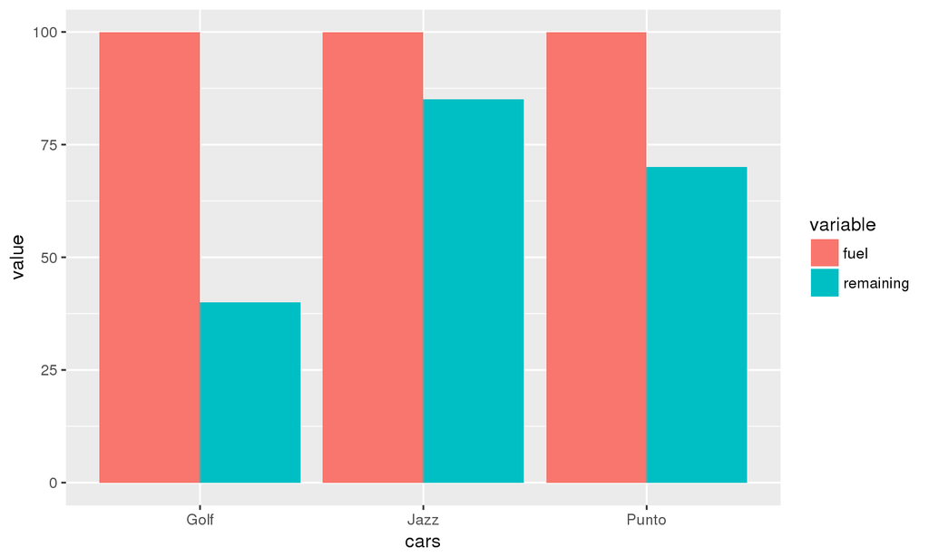

## Adding Some functions

- The previous code can be improved by adding some functions.
- That way we can repeat what we did by calling the functions.
- We don't need to copy, paste and change the code that way.

## Drive Car

1. For the amount of time specified in distance
2. Calculate the change in fuel level
   - If the fuel goes below 0% dont record the change
3. Return the changes in fuel usage

```r
drive_car <- function(starting_tank, ppm, distance) {
  tank_changes = c() # track the fuel usage using what % remains
  for(i in 0:distance) {
    new_tank <- starting_tank - (ppm * i)
    if(new_tank >= 0) {
      tank_changes <- c(tank_changes, new_tank) # only spend fuel if there was fuel to spend.
    }
  }
  return(tank_changes) # return the fuel usage
}
```

## Refuel Car

1. Record the amount of fuel added
2. Cap the fuel level at 100%
3. Return the vector of fuel level changes

```r
# creating a function to refuel a car
refuel_car <- function(tank_changes, tank_percentage) {
  new_tank <- tank_changes[length(tank_changes)] + tank_percentage
  if(new_tank > 100) {
    new_tank <- 100 # cant have more than a 100% full tank.
  }
  return(c(tank_changes, new_tank))
}
```

## Some data oriented functions

- Some functions will handle more abstract (or data oriented) aspects
- Padding of vectors in a collection such that they have equal length
- the construction of a dataframe so that plotting can be performed

## Pad Lengths

1. get the length of the longest vector
2. set the lengths of each vector to be that length

```r
pad_lengths <- function(...) {
  arguments <- list(...)
  max_length <- max(lengths(arguments))
  args <- lapply(arguments, function(x, max_len) {
    length(x) <- max_length
    return(x)
  }, max_len = max_length)
  return(args)
}
```

## Create Data Frame

1. Pad vectors passed to the function
2. Create the data frame and set the column names
3. Transform and 'melt' the dataframe

```r
create_data_frame <-function(car_names, ...) {
  car_data <- list(...)

  padded_fuel <- do.call(pad_lengths, car_data)
  car_frame <- data.frame(padded_fuel)
  colnames(car_frame) <- car_names

  car_frame.m <- melt(t(car_frame), id.vars="Cars",
                                    value.name ="Fuel",
                                    variable.name = "Time")
  colnames(car_frame.m) <- c('Cars', 'Time', 'Fuel')
  return(car_frame.m)
}
```

## Using the functions

- You now have some functions
- These can be used, shared and adapted
  - Reduced risk of side effects

```r
jazz_fuel_hist <- drive_car(100, 7.5, 10)

golf_fuel_hist <- drive_car(100, 2, 10)
golf_fuel_hist <- c(golf_fuel_hist,
                    drive_car(golf_fuel_hist[length(golf_fuel_hist)],
                              5, 10))

punto_fuel_hist <- drive_car(100, 10, 20)
punto_fuel_hist <- refuel_car(punto_fuel_hist, 70)
punto_fuel_hist <- c(punto_fuel_hist, drive_car(70, 10, 20))
```

## Using the functions

```r
car_data_frame <- create_data_frame(car_names = c('Punto',
                                                  'Golf',
                                                  'Jazz'),
                                   punto_fuel_hist,
                                   golf_fuel_hist,
                                   jazz_fuel_hist)

fuel_line_plot <-ggplot(car_data_frame, aes(x = Time,
                                            y = Fuel,
                                            group  = Cars,
                                            colour = Cars)) +
  geom_line() + geom_point()
```

## The resulting plot

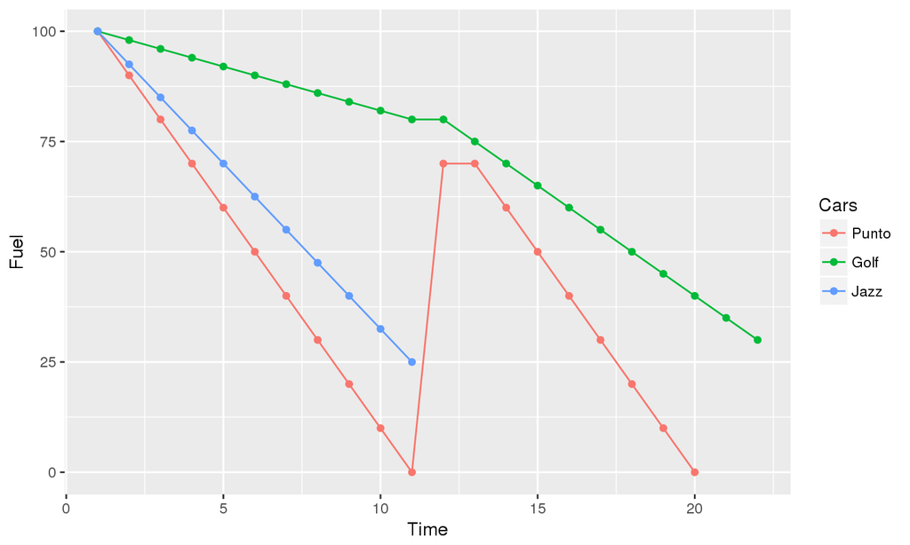

## This Isn't Perfect

- There is always way to improve Code
- The Drive function could be adapted
  - allow the user to pass a function that determines fuel usage
  - means it doesn't have to be a fixed linear usage
- The data is still being acted upon by functions
  - they could be grouped and protected further